# Causal Inference Project

19 June, 2023

## Load Necessary Packages & Helper Functions

```r
# needs to be done manually
# setwd(r"{J:\AID\Business Functions\Data and Analytical Services\
#       Impact Evaluation Research\Training_Upskilling Materials\
#       June 2023 Causal Inference Project (R)/}")
# ensure simstudy and grf are installed as well
source('helper_function.R')
print("Setup Complete")
```

```
## [1] "Setup Complete"
```

## Controlled / Fixed Effects Regression

Suppose we are interested in understanding the impact of customer satisfaction (*Customer Rating* - the average of all ratings provided by that customer in the past) on customer spend (*Customer Spend*).

The controls include *Customer Age*, a product fixed effect *Product FE*, a time fixed effect *Time FE* and the total number of purchases made in the past *Total Purchases*.

```r
# generate a simulated data set
dat <- sim_fixed_effects_df()

# explore data
colnames(dat)
```

```
## [1] "Customer_Spend"  "Customer_Rating" "Customer_Age"    "Product_FE"
## [5] "Time_FE"         "Total_Purchases"
```

```r
head(dat)
```

```
##   Customer_Spend Customer_Rating Customer_Age Product_FE   Time_FE
## 1            946            3.71           41  Product A Year 2014
## 2            849            4.65           30  Product A Year 2015
## 3            888            4.48           33  Product A Year 2016
## 4            850            5.00           28  Product A Year 2017
## 5            850            5.00           27  Product A Year 2018
## 6            868            3.49           28  Product A Year 2019
##   Total_Purchases
## 1             383
## 2             478
## 3             457
## 4             511
## 5             511
## 6             361
```

The data is quite noisy, but the correlation coefficient of 5% indicates there is a small positive relationship between Customer Rating and Customer Spend.

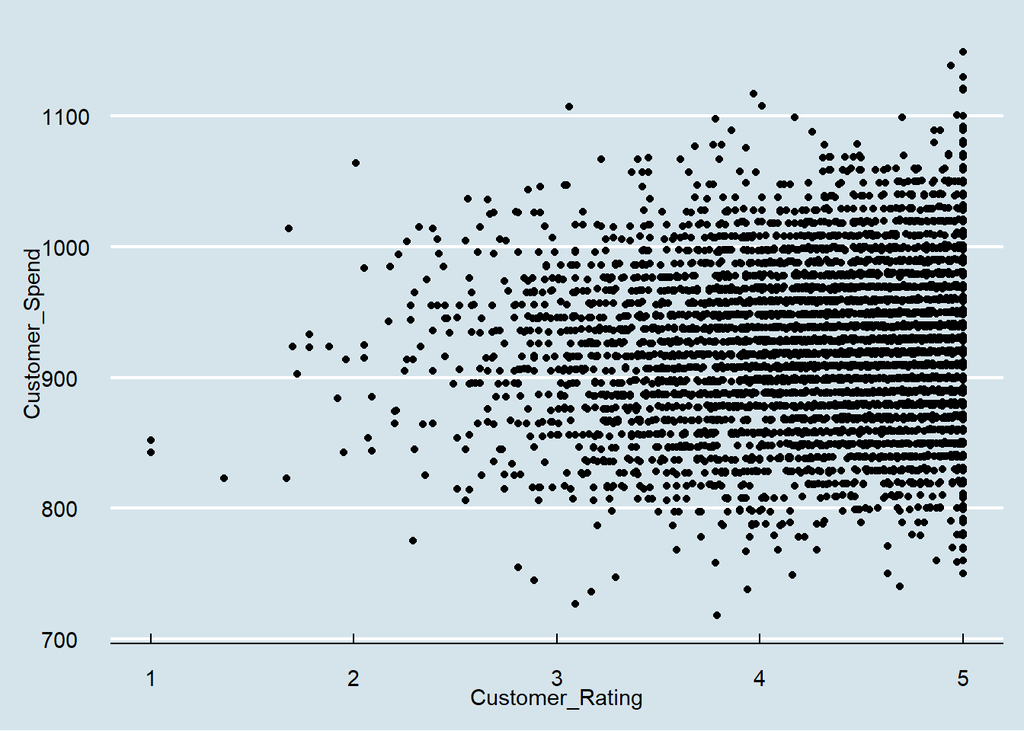

```r
# customer Spend vs. satisfaction
g1 <- dat %>%
  ggplot(aes(Customer_Rating, Customer_Spend)) +
  geom_point() +
  theme_economist() +
  scale_fill_economist()
g1
```

```r
cor(dat$Customer_Rating, dat$Customer_Spend)
```

```
## [1] 0.04975506
```

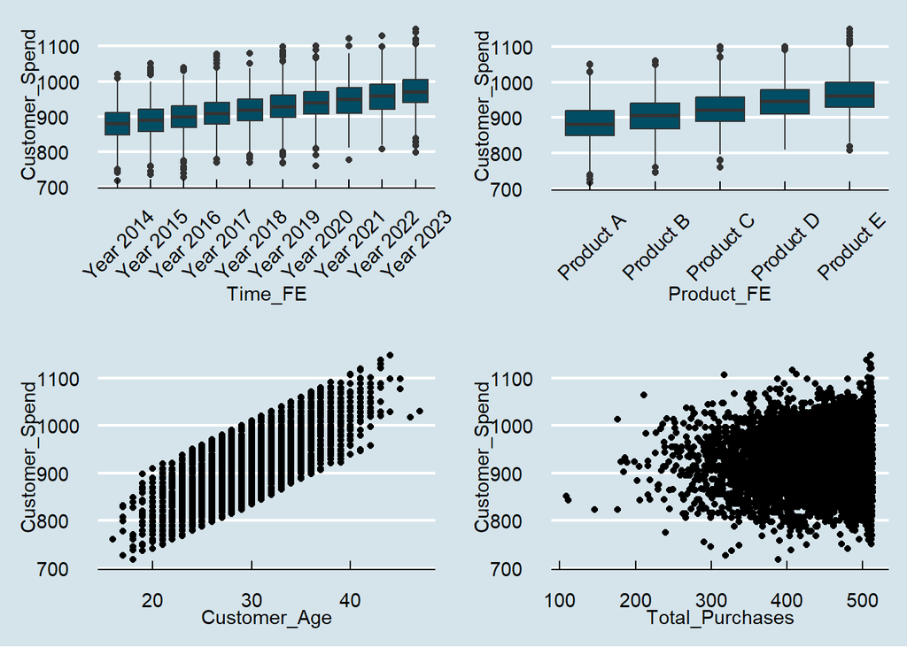

```r
# customer Spend vs. time
g2 <- dat %>%
  ggplot(aes(Time_FE, Customer_Spend, fill = "A")) +
  geom_boxplot() +
  theme_economist() +
  scale_fill_economist() +
  theme(legend.position = "none",
        axis.text.x = element_text(angle = 45, vjust = 0.5))

# customer spend vs. product
g3 <- dat %>%
  ggplot(aes(Product_FE, Customer_Spend, fill = "A")) +
  geom_boxplot() +
  theme_economist() +
  scale_fill_economist() +
  theme(legend.position = "none",
        axis.text.x = element_text(angle = 45, vjust = 0.5))

# Customer spend vs. customer Age
g4 <- dat %>%
  ggplot(aes(Customer_Age, Customer_Spend, fill = "A")) +
  geom_point() +
  theme_economist() +
  scale_fill_economist() +
  theme(legend.position = "none")

# Customer spend vs. total purchases
g5 <- dat %>%
  ggplot(aes(Total_Purchases, Customer_Spend, fill = "A")) +
  geom_point() +
  theme_economist() +
  scale_fill_economist() +
  theme(legend.position = "none")

# combind all plots
grid.arrange(g2, g3, g4, g5, nrow = 2)
```

```r
# observe differences across time & products & customer age
# need to include in regression to control for their effects
```

```r
# compare controlled reg/fixed effect models

# naive regression; no controls
model1 <- lm(Customer_Spend ~ Customer_Rating, data = dat)

# control for customer age only
model2 <- lm(Customer_Spend ~ Customer_Rating + Customer_Age, data = dat)

# control for product and time fixed effects only
model3 <- lm(Customer_Spend ~ Customer_Rating + Product_FE + Time_FE, data = dat)

# full controls; and included variable bias of total purchases
model4 <- lm(Customer_Spend ~., data = dat)

# full controls; no included variable bias
model5 <- lm(Customer_Spend ~. -Total_Purchases, data = dat)
```

The table below presents a summary of all the regression models run.

- Column 1: The baseline univariate linear regression. It has a very low R-squared and a coefficient way off from the known true value (recall this is a simulated dataset). As such, it’s a poor model that suffers from omitted variable bias.
- Columns 2 and 3: Add various controls to the model. R-squared increases by a significant amount, and the coefficient gets closer to the true value, but is still someway off. Hence, these models still suffer from omitted variable bias.
- Column 4: The model includes Included Variable Bias (IVB), which indicates it can still impact the regression results even when the model is explaining 100% of the variation in the data (R-squared = 1).
- Column 5: Shows the true model form for this data. R-squared is 1 and the true value of Customer Rating has been derived. We can therefore conclude that there is a positive and significant causal relationship between Customer Rating and Customer Spend.

```r
# see here for more info on stargazer:
# (1) https://cran.r-project.org/web/packages/stargazer/vignettes/stargazer.pdf
# (2) https://www.jakeruss.com/cheatsheets/stargazer/

# view coefficient of interest in each regression model
stargazer(model1, model2, model3, model4, model5, type = "text",
          style = "aer", omit = c("Constant", "Customer_Age", "Product_FE",
                                  "Time_FE", "Total_Purchases"),
          column.labels = c("Y~X", "Y~X+C", "Y~X+FE", "Y~X+C+FE+IVB", "Y~X+C+FE"),
          dep.var.labels = "Controlled / Fixed Effects Regression",
          omit.stat = c("f", "ser", "rsq", "n"),
          notes = c("True Coef on X=2"),
          add.lines = list(c("Add Controls", "No", "Yes", "No", "Yes", "Yes"),
                         c("Fixed effects", "No", "No", "Yes", "Yes", "Yes"),
                         c("Included Variable Bias", "No", "No", "No", "Yes", "No")))
```

```
##
## =======================================================================
##                             Controlled / Fixed Effects Regression
##                          Y~X     Y~X+C    Y~X+FE  Y~X+C+FE+IVB Y~X+C+FE
##                          (1)      (2)      (3)        (4)        (5)
## -----------------------------------------------------------------------
## Customer_Rating        4.934*** 3.367*** 3.545***   2.451***   1.994***
##                        (0.991)  (0.701)  (0.698)    (0.620)    (0.011)
##
## Add Controls              No      Yes       No        Yes        Yes
## Fixed effects             No       No      Yes        Yes        Yes
## Included Variable Bias    No       No       No        Yes         No
## Adjusted R2             0.002    0.501    0.506      1.000      1.000
## -----------------------------------------------------------------------
## Notes:                 ***Significant at the 1 percent level.
##                        **Significant at the 5 percent level.
##                        *Significant at the 10 percent level.
##                        True Coef on X=2
```

These days, controlled regression isn’t a preferred approach as the true value of the target explanatory variable isn’t typically known and therefore it’s harder to identify whether you have the appropriate model or not and hence the form of the causal relationship between the variables.